# T20 Match Analysis

T Baynes

December 22, 2015

This is my first experiment with uing R Markdown.

First load some R packages and the dataframes of match data that we processed from cricsheet.org using `source("process_cricheet.R")`:

```r
library(dplyr)
library(tidyr)
library(ggplot2)
load("matches.RData")
load("ball_by_ball.RData")
```

Then lets do some calculations to work out the win, losses, no results and ties for each team:

```r
team_summary <- matches_df %>%
    group_by(teams) %>%
    summarise(games = length(teams),
              wins = sum(outcome.winner==teams, na.rm = TRUE),
              losses = sum(outcome.winner!= teams, na.rm = TRUE) - sum(is.na(outcome.winner), na.rm = TRUE),
              no_result = sum(result == "no result", na.rm = TRUE),
              tie = sum(outcome.result == "tie", na.rm= TRUE))

team_summary
```

```
## Source: local data frame [17 x 6]
##
##           teams games  wins losses no_result   tie
##           (chr) (int) (int)  (int)     (int) (int)
## 1   Afghanistan     5     1      4         0     0
## 2     Australia    45    22     19         1     1
## 3    Bangladesh    23     6     17         0     0
## 4       Bermuda     1     0      1         0     0
## 5        Canada     3     1      2         0     0
## 6       England    50    26     16         4     0
## 7         India    39    20     17         0     1
## 8       Ireland    11     2      5         2     0
## 9         Kenya     9     3      6         0     0
## 10  Netherlands     7     3      4         0     0
## 11  New Zealand    56    26     22         1     3
## 12     Pakistan    49    28     19         0     1
## 13     Scotland     5     1      4         0     0
## 14 South Africa    54    33     19         1     0
## 15    Sri Lanka    41    23     18         0     0
## 16  West Indies    45    22     17         1     2
## 17     Zimbabwe    15     3     12         0     0
```

And maybe a plot:

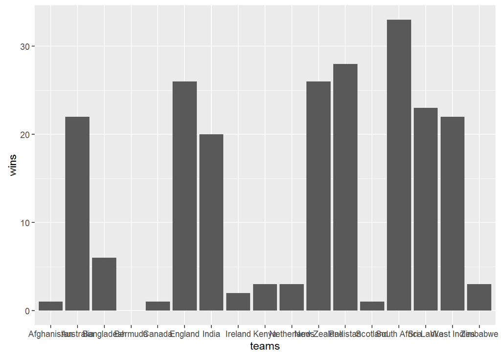

```r
ggplot(team_summary, aes(x = teams, y = wins)) + geom_bar(stat = "identity")
```

But that plot looks pretty hideous, let’s try and sort it out. First lets order the bars and fix the x axis labels.

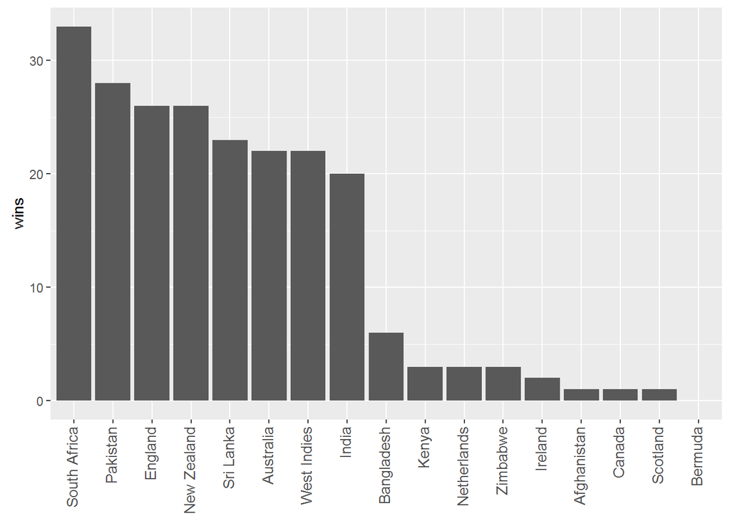

```r
team_summary$teams <- factor(team_summary$teams, levels = team_summary$teams[order(team_summary$wins, decreasing = TRUE)])
ggplot(team_summary, aes( x = teams, y = wins)) + geom_bar(stat = "identity") +
  theme(axis.title.x = element_blank(),
        axis.text.x  = element_text(angle=90, vjust=0.3, hjust = 1, size=10))
```

That’s a lot better, but I don’t like the standard colours, so let’s go for `theme_bw()` and change the bar colour to blue.

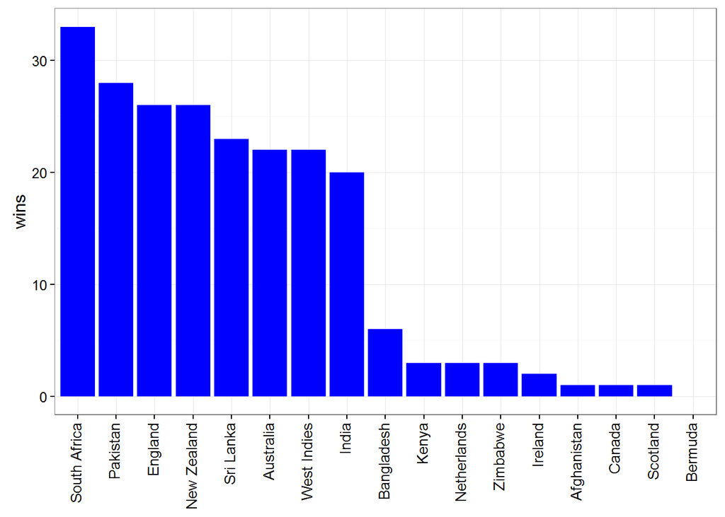

```r
ggplot(team_summary, aes( x = teams, y = wins)) + geom_bar(stat = "identity", fill = "Blue") +
  theme_bw() +
  theme(axis.title.x = element_blank(),
        axis.text.x  = element_text(angle=90, vjust=0.3, hjust = 1, size=10))
```

Much, better, but it’s still hard to read the axis labels, let’s go for horizontal bars.

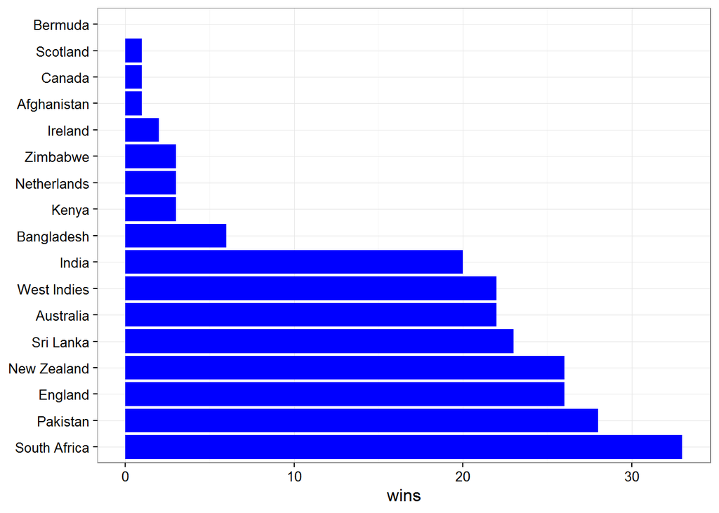

```r
ggplot(team_summary, aes( x = teams, y = wins)) + geom_bar(stat = "identity", fill = "Blue") +
  theme_bw() +
  theme(axis.title.y = element_blank()) +
  coord_flip()
```

Hmm, now the bars are the wrong way around, so we’ll have to reorder the levels of the teams again

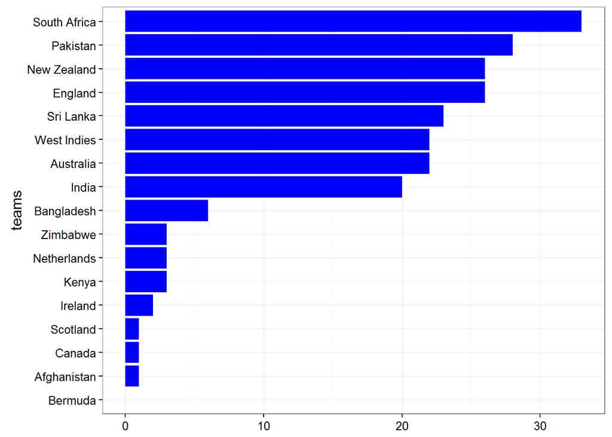

```r
team_summary$teams <- factor(team_summary$teams, levels = team_summary$teams[order(team_summary$wins, decreasing = FALSE)])
ggplot(team_summary, aes( x = teams, y = wins)) + geom_bar(stat = "identity", fill = "Blue") +
  theme_bw() +
  theme(axis.title.x = element_blank()) +
  coord_flip()
```

What about a facetted plot showing wins and losses? First we will need to rearrange the `team_summary` dataframe into a tidy format, after reordering the levels of teams again.

```r
team_summary$teams <- factor(team_summary$teams, levels = team_summary$teams[order(team_summary$wins, decreasing = TRUE)])
team_summary_tidy <- team_summary %>%
  select(-games) %>%
  gather(outcome, number, -teams) %>%
  arrange(teams)

head(team_summary_tidy)
```

```
## Source: local data frame [6 x 3]
##
##          teams   outcome number
##         (fctr)    (fctr)  (int)
## 1 South Africa      wins     33
## 2 South Africa    losses     19
## 3 South Africa no_result      1
## 4 South Africa       tie      0
## 5     Pakistan      wins     28
## 6     Pakistan    losses     19
```

Now we have the data in a tidy format it’s much easier to do cleverer stuff in ggplot.

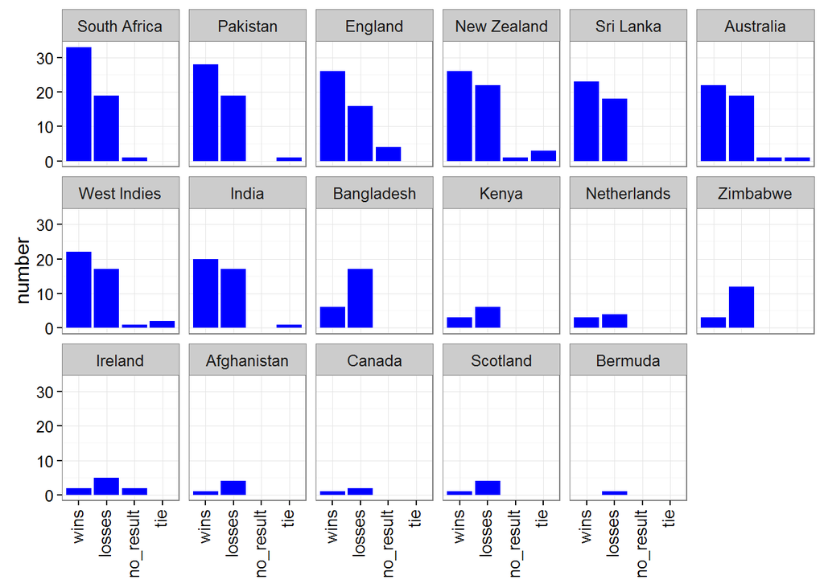

```r
ggplot(team_summary_tidy) +
  geom_bar(aes(x = outcome, y = number), stat = "identity", fill = "Blue") +
  theme_bw() +
  theme(axis.title.x = element_blank(),
        axis.text.x  = element_text(angle=90, vjust=0.3, hjust = 1, size=10)) +
  facet_wrap(~teams, ncol = 6)
```

And maybe we’re only interested in the test playing nations.

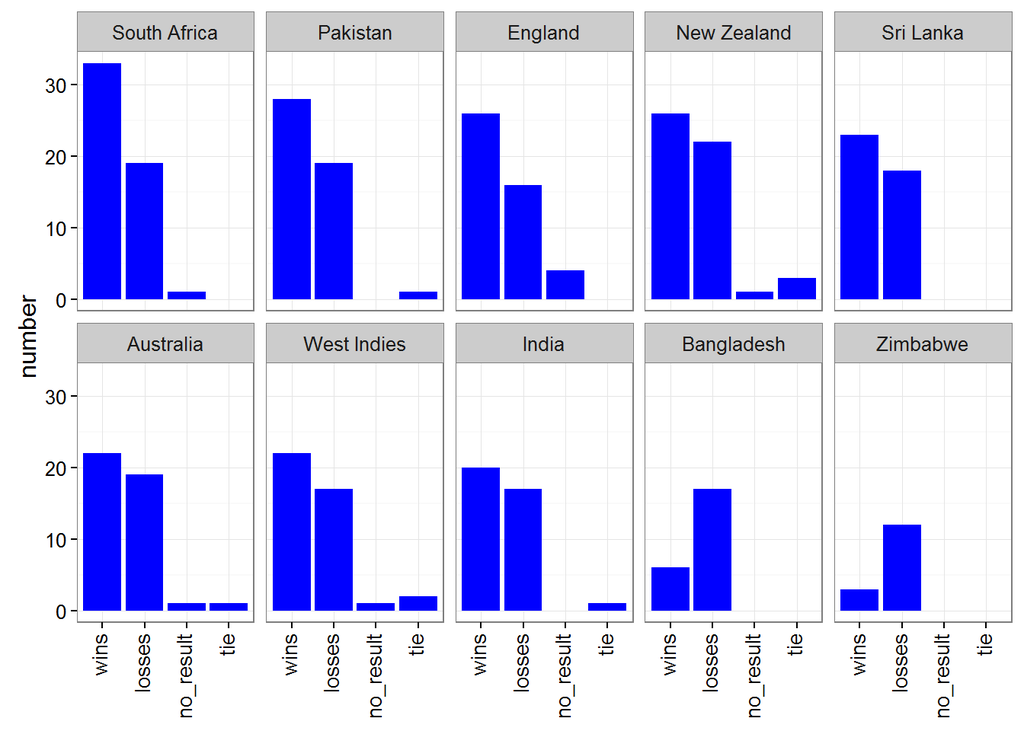

```r
test_team_summary_tidy <- team_summary_tidy %>%
  filter(teams %in% c("England", "Australia", "India", "Pakistan", "South Africa", "Sri Lanka",
                      "New Zealand", "West Indies", "Bangladesh", "Zimbabwe"))

ggplot(test_team_summary_tidy) +
  geom_bar(aes(x = outcome, y = number), stat = "identity", fill = "Blue") +
  theme_bw() +
  theme(axis.title.x = element_blank(),
        axis.text.x  = element_text(angle=90, vjust=0.3, hjust = 1, size=10)) +
  facet_wrap(~teams, ncol = 5)
```